# Exploration of Red Wine Attributes

Raymond Atherley

### This report explores the chemical attributes that affect the quality of red

### wine for approximately 1600 wines.

### Reviewing the structure and datatypes of the dataset

```
##   fixed.acidity volatile.acidity citric.acid residual.sugar chlorides
## 1           7.4             0.70        0.00            1.9     0.076
## 2           7.8             0.88        0.00            2.6     0.098
## 3           7.8             0.76        0.04            2.3     0.092
## 4          11.2             0.28        0.56            1.9     0.075
## 5           7.4             0.70        0.00            1.9     0.076
## 6           7.4             0.66        0.00            1.8     0.075
##   free.sulfur.dioxide total.sulfur.dioxide density   pH sulphates alcohol
## 1                  11                   34  0.9978 3.51      0.56     9.4
## 2                  25                   67  0.9968 3.20      0.68     9.8
## 3                  15                   54  0.9970 3.26      0.65     9.8
## 4                  17                   60  0.9980 3.16      0.58     9.8
## 5                  11                   34  0.9978 3.51      0.56     9.4
## 6                  13                   40  0.9978 3.51      0.56     9.4
##   quality
## 1       5
## 2       5
## 3       5
## 4       6
## 5       5
## 6       5
```

```
## 'data.frame':    1599 obs. of  12 variables:
##  $ fixed.acidity       : num  7.4 7.8 7.8 11.2 7.4 7.4 7.9 7.3 7.8 7.5 ...
##  $ volatile.acidity    : num  0.7 0.88 0.76 0.28 0.7 0.66 0.6 0.65 0.58 0.5 ...
##  $ citric.acid         : num  0 0 0.04 0.56 0 0 0.06 0 0.02 0.36 ...
##  $ residual.sugar      : num  1.9 2.6 2.3 1.9 1.9 1.8 1.6 1.2 2 6.1 ...
##  $ chlorides           : num  0.076 0.098 0.092 0.075 0.076 0.075 0.069 0.065 0.073 0.071 ...
##  $ free.sulfur.dioxide : num  11 25 15 17 11 13 15 15 9 17 ...
##  $ total.sulfur.dioxide: num  34 67 54 60 34 40 59 21 18 102 ...
##  $ density             : num  0.998 0.997 0.997 0.998 0.998 ...
##  $ pH                  : num  3.51 3.2 3.26 3.16 3.51 3.51 3.3 3.39 3.36 3.35 ...
##  $ sulphates           : num  0.56 0.68 0.65 0.58 0.56 0.56 0.46 0.47 0.57 0.8 ...
##  $ alcohol             : num  9.4 9.8 9.8 9.8 9.4 9.4 9.4 10 9.5 10.5 ...
##  $ quality             : int  5 5 5 6 5 5 5 7 7 5 ...
```

```
##  fixed.acidity   volatile.acidity  citric.acid    residual.sugar
##  Min.   : 4.60   Min.   :0.1200   Min.   :0.000   Min.   : 0.900
##  1st Qu.: 7.10   1st Qu.:0.3900   1st Qu.:0.090   1st Qu.: 1.900
##  Median : 7.90   Median :0.5200   Median :0.260   Median : 2.200
##  Mean   : 8.32   Mean   :0.5278   Mean   :0.271   Mean   : 2.539
##  3rd Qu.: 9.20   3rd Qu.:0.6400   3rd Qu.:0.420   3rd Qu.: 2.600
##  Max.   :15.90   Max.   :1.5800   Max.   :1.000   Max.   :15.500
##    chlorides       free.sulfur.dioxide total.sulfur.dioxide
##  Min.   :0.01200   Min.   : 1.00       Min.   :  6.00
##  1st Qu.:0.07000   1st Qu.: 7.00       1st Qu.: 22.00
##  Median :0.07900   Median :14.00       Median : 38.00
##  Mean   :0.08747   Mean   :15.87       Mean   : 46.47
##  3rd Qu.:0.09000   3rd Qu.:21.00       3rd Qu.: 62.00
##  Max.   :0.61100   Max.   :72.00       Max.   :289.00
##     density             pH          sulphates         alcohol
##  Min.   :0.9901   Min.   :2.740   Min.   :0.3300   Min.   : 8.40
##  1st Qu.:0.9956   1st Qu.:3.210   1st Qu.:0.5500   1st Qu.: 9.50
##  Median :0.9968   Median :3.310   Median :0.6200   Median :10.20
##  Mean   :0.9967   Mean   :3.311   Mean   :0.6581   Mean   :10.42
##  3rd Qu.:0.9978   3rd Qu.:3.400   3rd Qu.:0.7300   3rd Qu.:11.10
##  Max.   :1.0037   Max.   :4.010   Max.   :2.0000   Max.   :14.90
##     quality
##  Min.   :3.000
##  1st Qu.:5.000
##  Median :6.000
##  Mean   :5.636
##  3rd Qu.:6.000
##  Max.   :8.000
```

### Input variables (based on physicochemical tests):

1. fixed acidity (tartaric acid - g / dm^3)
2. volatile acidity (acetic acid - g / dm^3)
3. citric acid (g / dm^3)
4. residual sugar (g / dm^3)
5. chlorides (sodium chloride - g / dm^3
6. free sulfur dioxide (mg / dm^3)
7. total sulfur dioxide (mg / dm^3)
8. density (g / cm^3)
9. pH
10. sulphates (potassium sulphate - g / dm^3)
11. alcohol (% by volume)

Output variable (based on sensory data):  
12. quality (score between 0 and 10)

Note: grams/decimeter (g / dm^3)  
A decimeter cubed (dm^3) is equal to one liter (L)

# Univariate Plots Section

## Histograms of the above variables will be plotted below.

#### A histogram of each variable is plotted as well as a summary of the statistics

Checking for any ‘na’ values. No na values found.

```
##  [1] fixed.acidity        volatile.acidity     citric.acid
##  [4] residual.sugar       chlorides            free.sulfur.dioxide
##  [7] total.sulfur.dioxide density              pH
## [10] sulphates            alcohol              quality
## <0 rows> (or 0-length row.names)
```

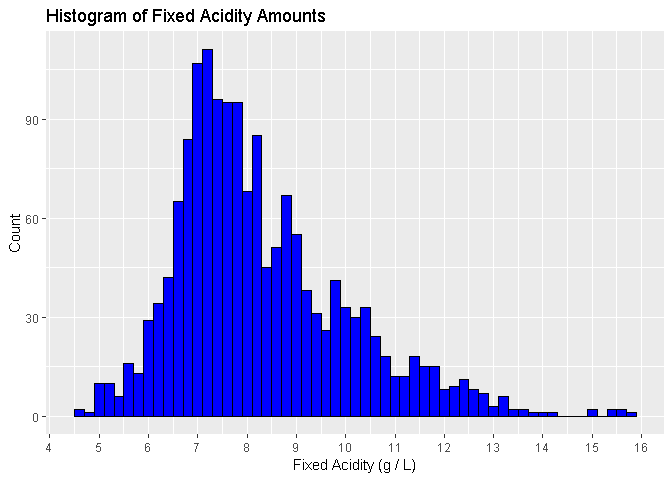

```
##    Min. 1st Qu.  Median    Mean 3rd Qu.    Max.
##    4.60    7.10    7.90    8.32    9.20   15.90
```

Fixed acidity in wine. The highest frequency of acidity is around 7 g/L. The plot looks like a normal distribution slightly skewed to the right with some outliers around 15 to 16 grams/L

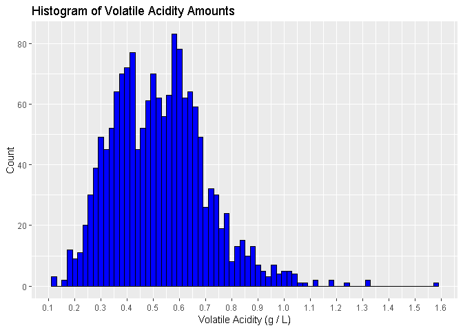

The amount of volative acidity is about a tenth of the fixed acidity. It appears to have bimodal distribution with peaks at 0.4 and 0.6 g/L.

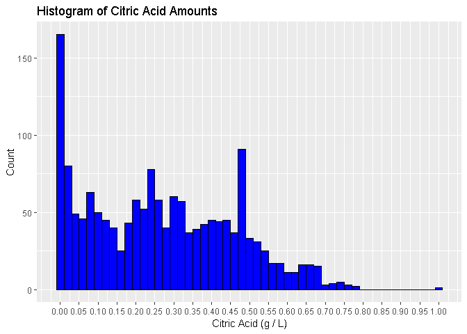

```
##    Min. 1st Qu.  Median    Mean 3rd Qu.    Max.
##   0.000   0.090   0.260   0.271   0.420   1.000
```

From the distribution of the citric acid, over 150 wines have very little or no citric acid. This is the highest peak in the plot shows (zero) 0 g/L. The distribution of the citric acid is varied. Two other peaks that we see are around 0.25 and 0.48 g/L. The median is 0.26 g/L.

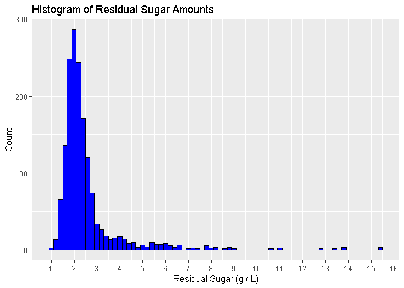

```
##    Min. 1st Qu.  Median    Mean 3rd Qu.    Max.
##   0.900   1.900   2.200   2.539   2.600  15.500
```

For the residual sugar, the distribution appears to be a very narrow normal distribution skewed to the right. The great majority of wines have a concentration of sugar 2.6 g/L and below. However, there are relatively few wines that have amounts up to 15.5 g/L. Wines greater than 45 g/L are considered sweet according to the database wine information. However, the maximum residual sugar shown is 15.5 g/L, so none of the wines are considered sweet.

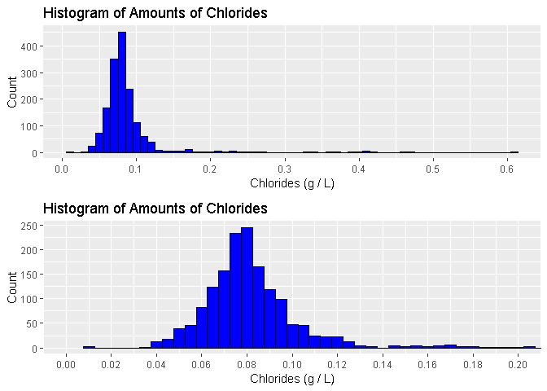

```
##    Min. 1st Qu.  Median    Mean 3rd Qu.    Max.
## 0.01200 0.07000 0.07900 0.08747 0.09000 0.61100
```

We also see for the chlorides content, the distribution appears to be a very narrow normal distribution skewed to the right. The great majority of wines (third quartile) have a concentration of chloride 0.09 g/L and below. However, there are relatively few wines that have amounts up to 0.611 g/L.

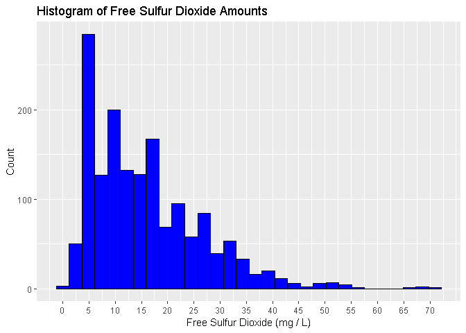

```
##    Min. 1st Qu.  Median    Mean 3rd Qu.    Max.
##    1.00    7.00   14.00   15.87   21.00   72.00
```

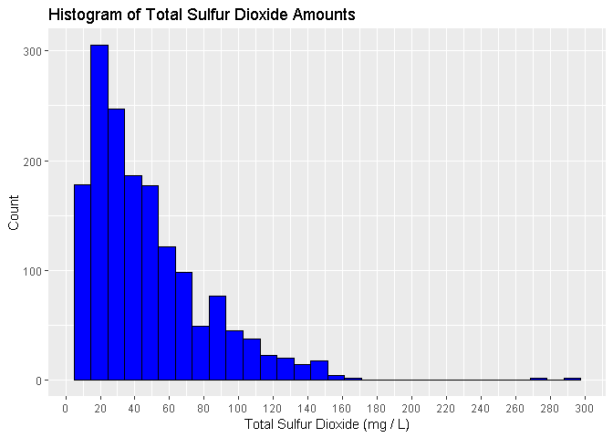

```
##    Min. 1st Qu.  Median    Mean 3rd Qu.    Max.
##    6.00   22.00   38.00   46.47   62.00  289.00
```

We see the total median for free sulfur dioxide is 14 mg/L while the median for total sulfur dioxide is 38 mg/L.

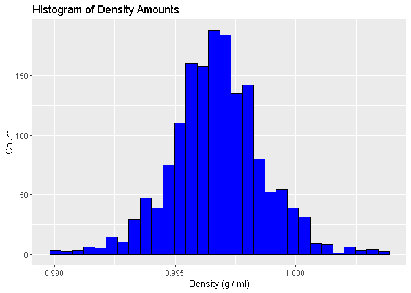

```
##    Min. 1st Qu.  Median    Mean 3rd Qu.    Max.
##  0.9901  0.9956  0.9968  0.9967  0.9978  1.0037
```

The density of the wines are close to that of water, which is about 1 g/ml. The range of density values are from 0.99 to 1.0037 g/ml, which is unremarkable.

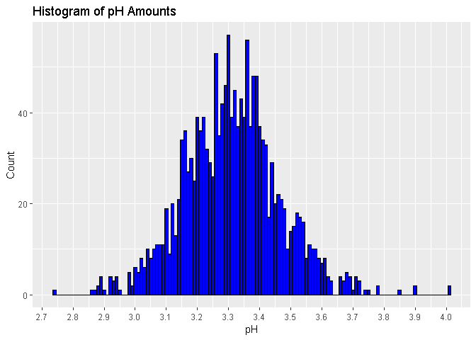

```
##    Min. 1st Qu.  Median    Mean 3rd Qu.    Max.
##   2.740   3.210   3.310   3.311   3.400   4.010
```

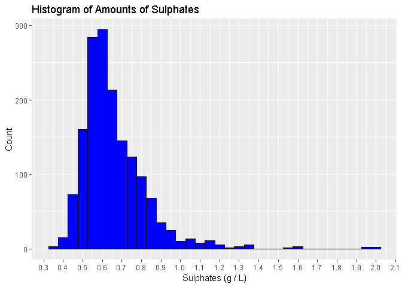

```
##    Min. 1st Qu.  Median    Mean 3rd Qu.    Max.
##  0.3300  0.5500  0.6200  0.6581  0.7300  2.0000
```

The highest peaks on the plot is between 0.5 and 0.6 g/L. Sulfates can affect the amount of Sulfur Dioxide in the wine. Some people are also none to be negatively affected by the sulfate content in red wines.

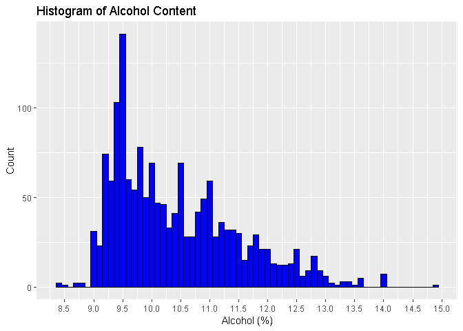

```
##    Min. 1st Qu.  Median    Mean 3rd Qu.    Max.
##    8.40    9.50   10.20   10.42   11.10   14.90
```

```
## [1] "The mode is: 9.5"
```

The alcohol content plot is quite varied, but is skewed to the right. The range is from 8.4 to 14.90 percent alcohol. Note, however, that the median amount of alcohol content is 10.20. In addition, the greatest count is around 9.5 percent alcohol.

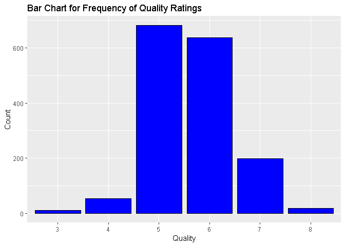

Count of Quality Scores

```
##
##   3   4   5   6   7   8
##  10  53 681 638 199  18
```

Although the scoring is between 0 and 10, the range of quality ratings is between 3 and 8 for the wines in this dataset. We see, however, that the great majority of the ratings chosen by the experts are 5 and 6.

A subset of wines with high alcohol content was created to check if this has an effect on the quality rating. High content was choosen as wines with an alcohol content at and above the 90% quantile. The result was wines with an alcohol content of 12% or higher.

The summary of the statistics for the high alcohol subset was printed below.

```
##    Min. 1st Qu.  Median    Mean 3rd Qu.    Max.
##   12.00   12.20   12.50   12.61   12.80   14.90
```

Percentages of each quality ratings of the whole dataset (top) vs the high alcohol content subset.

```
##
##          3          4          5          6          7          8
##  0.6253909  3.3145716 42.5891182 39.8999375 12.4452783  1.1257036
```

```
##
##         4         5         6         7         8
##  1.234568  7.407407 45.061728 40.740741  5.555556
```

The percentages of quality ratings calculated.The whole dataset is shown first and the high content wines are shown second. As we see above, there is an effect. For high content wines, only 7.4% received a rating of 5, 45.1% received a rating of 6, while 40.7% received a rating of 7. Compared the whole database, 42.6% of the wine received a rating of 5 and 39.9% received a rating of 6, and only 12.4% received a rating of 7.

A variable was created to check the sugar to chlorides (salt) ratio. The great majority of wines show a ratio of sugar to salt between 20 to 35.

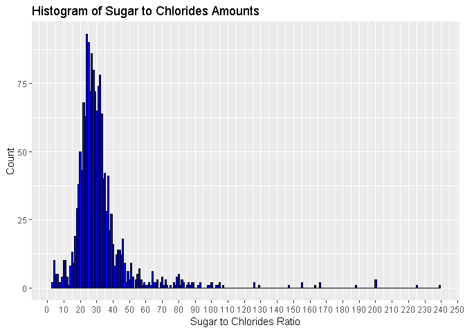

```
##    Min. 1st Qu.  Median    Mean 3rd Qu.    Max.
##   2.946  23.656  28.378  32.013  34.352 238.889
```

# Univariate Analysis

### What is the structure of your dataset?

The wines attributes are generally acid, sugar, salt, sulfur dioxide and sulphates, density, and, of course, alcohol amount. acid - fixed acidity, volative acidity, pH sugar - residual sugar salt - sodium chloride sulfur dioxide - free and total sulfur dioxide sulphates - postassium sulphate alcohol quality

### What is/are the main feature(s) of interest in your dataset?

The main features are alcohol and quality rating. However, we will look at others to see the affect on the wine quality.

### What other features in the dataset do you think will help support your investigation into your feature(s) of interest?

I think sugar content, acidity and sulfur content will also affect the quality rating.

### Did you create any new variables from existing variables in the dataset?

Yes. A variable was created to check the sugar to chlorides (salt) ratio. The great majority of wines show a ratio of sugar to salt between 20 to 35. However, there were some outliers up to 238.8.

### Of the features you investigated, were there any unusual distributions? Did you perform any operations on the data to tidy, adjust, or change the form of the data? If so, why did you do this?

The distribution of citric acid was alternating and varied. The largest peak was near the zero content value, however, there were other peaks. I was surprised that most of the wines only had a rating of 5 or 6 and not higher. In addition, the distributions for the residual sugar and salt looked similar even though the actual values were very different. No. I did not have to tidy or adjust the data.

# Bivariate Plots Section

We calculated the correlation of the dataset to help determine which variables affect the quality and other variables. The created variable sugar_to_chlorides was removed.

```
##                      fixed.acidity volatile.acidity citric.acid
## fixed.acidity                1.000           -0.256       0.672
## volatile.acidity            -0.256            1.000      -0.552
## citric.acid                  0.672           -0.552       1.000
## residual.sugar               0.115            0.002       0.144
## chlorides                    0.094            0.061       0.204
## free.sulfur.dioxide         -0.154           -0.011      -0.061
## total.sulfur.dioxide        -0.113            0.076       0.036
## density                      0.668            0.022       0.365
## pH                          -0.683            0.235      -0.542
## sulphates                    0.183           -0.261       0.313
## alcohol                     -0.062           -0.202       0.110
## quality                      0.124           -0.391       0.226
##                      residual.sugar chlorides free.sulfur.dioxide
## fixed.acidity                 0.115     0.094              -0.154
## volatile.acidity              0.002     0.061              -0.011
## citric.acid                   0.144     0.204              -0.061
## residual.sugar                1.000     0.056               0.187
## chlorides                     0.056     1.000               0.006
## free.sulfur.dioxide           0.187     0.006               1.000
## total.sulfur.dioxide          0.203     0.047               0.668
## density                       0.355     0.201              -0.022
## pH                           -0.086    -0.265               0.070
## sulphates                     0.006     0.371               0.052
## alcohol                       0.042    -0.221              -0.069
## quality                       0.014    -0.129              -0.051
##                      total.sulfur.dioxide density     pH sulphates alcohol
## fixed.acidity                      -0.113   0.668 -0.683     0.183  -0.062
## volatile.acidity                    0.076   0.022  0.235    -0.261  -0.202
## citric.acid                         0.036   0.365 -0.542     0.313   0.110
## residual.sugar                      0.203   0.355 -0.086     0.006   0.042
## chlorides                           0.047   0.201 -0.265     0.371  -0.221
## free.sulfur.dioxide                 0.668  -0.022  0.070     0.052  -0.069
## total.sulfur.dioxide                1.000   0.071 -0.066     0.043  -0.206
## density                             0.071   1.000 -0.342     0.149  -0.496
## pH                                 -0.066  -0.342  1.000    -0.197   0.206
## sulphates                           0.043   0.149 -0.197     1.000   0.094
## alcohol                            -0.206  -0.496  0.206     0.094   1.000
## quality                            -0.185  -0.175 -0.058     0.251   0.476
##                      quality
## fixed.acidity          0.124
## volatile.acidity      -0.391
## citric.acid            0.226
## residual.sugar         0.014
## chlorides             -0.129
## free.sulfur.dioxide   -0.051
## total.sulfur.dioxide  -0.185
## density               -0.175
## pH                    -0.058
## sulphates              0.251
## alcohol                0.476
## quality                1.000
```

Interestingly, with a value of 0.014 residual sugar does not show a strong correlation with quality. In addition,pH only shows a -0.058 effect.

### Correlation Plot

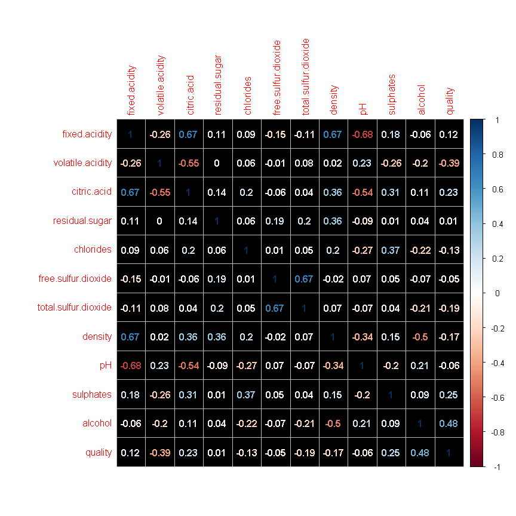

A linear regression equation was used to determine the correlation coefficient to verify three independent variables that greatly influence the quality rating. These variables are alcohol, sulphates, and volatile acidity.

#### Linear Regression Equation ( three significant variables)

```
##
## Calls:
## rwine.M1: lm(formula = quality ~ alcohol, data = rwine)
## rwine.M2: lm(formula = quality ~ alcohol + sulphates, data = rwine)
## rwine.M3: lm(formula = quality ~ alcohol + sulphates + volatile.acidity,
##     data = rwine)
##
## ===========================================================
##                      rwine.M1     rwine.M2     rwine.M3
## -----------------------------------------------------------
##   (Intercept)          1.875***     1.375***     2.611***
##                       (0.175)      (0.177)      (0.196)
##   alcohol              0.361***     0.346***     0.309***
##                       (0.017)      (0.016)      (0.016)
##   sulphates                         0.994***     0.679***
##                                    (0.102)      (0.101)
##   volatile.acidity                              -1.221***
##                                                 (0.097)
## -----------------------------------------------------------
##   R-squared            0.227        0.270        0.336
##   N                 1599         1599         1599
## ===========================================================
##   Significance: *** = p < 0.001; ** = p < 0.01;
##                 * = p < 0.05
```

When we calculated the correlation coefficient for alcohol only.

```
## [1] "The correlation coefficient is:  0.475"
```

Then we calculated the correlation coefficient for the three variables.

```
## [1] "The correlation coefficient is:  0.579"
```

It appears that the alcohol content has the most influence on quality with a correlation coefficient of 47.5%.

## Bivariate Plots of Variables vs Quality

### Plots with jitter (overlayed with boxplots) for the variables vs quality (rating)

We will use boxplots to see the overall trend of the various variables vs the quality rating.

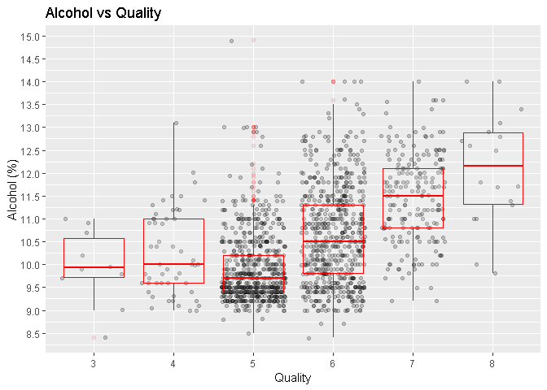

The plot above shows that the wines that received the higher quality ratings had a higher alcohol content. Except for the rating value of 5, the plot shows a positive trend where the quality rating tend to increase as the alcohol content increases.

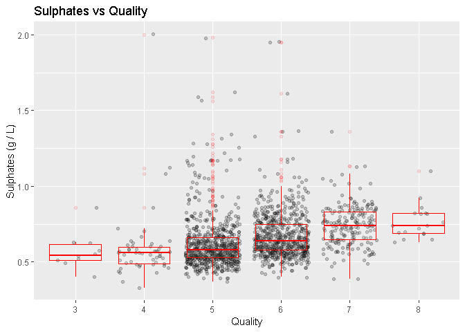

The plot above shows a positive trend for the amount sulphates vs the quality rating the wines received.

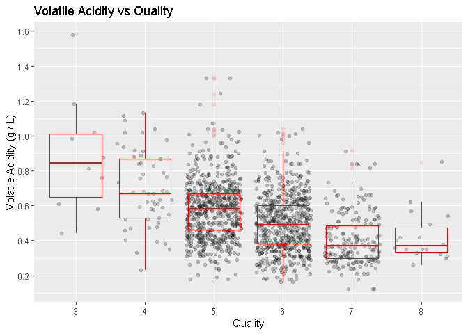

On average, there appears to be a negative relationship between the volatile acidity and quality rating. The lower the volatile acidity, the higher the quality rating the wine receives.

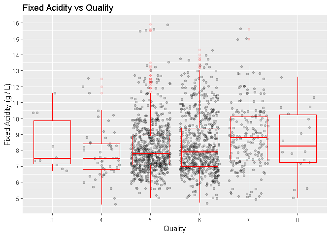

The trend of fixed acidity and the quality is not consistent, so we cannot state a direct relationship between the two variables

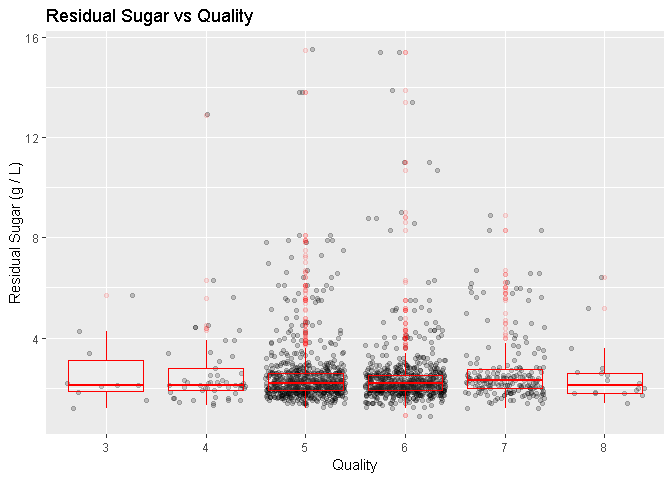

It appears that the residual sugar does not have much affect on the quality of the wine as the trend generally remains level.

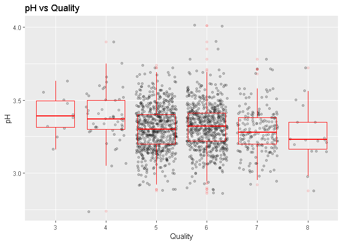

We do see an affect of the pH on the quality of the wine. The less the pH value, the better quality rating the wine receives.

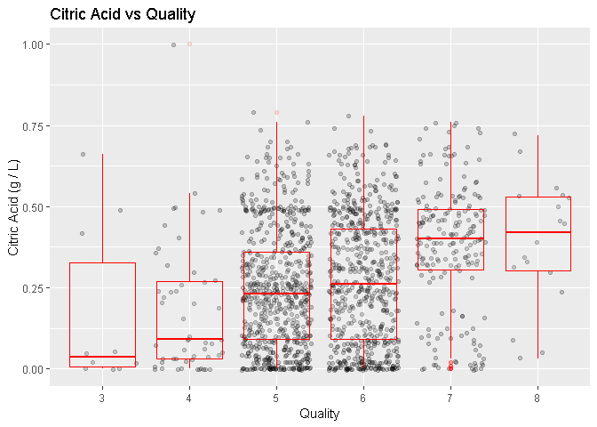

Citric acid has a positive affect on the quality of the wine. The more citric acid the better rating the wine receives.

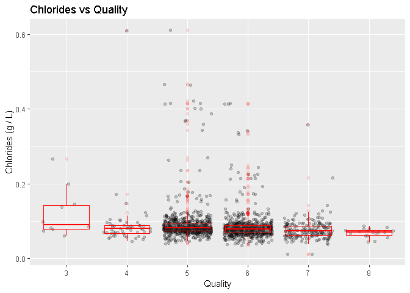

There is a slight negative trend for the chlorides content in the wines.

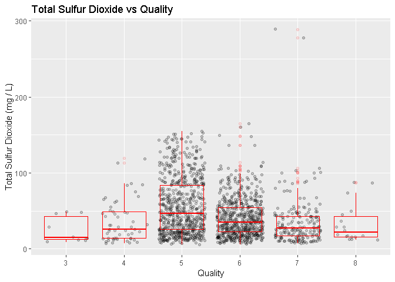

Interestingly, the total Sulfur dioxide has a slight concave trend. The amount of total sulfur dioxide increases until quality rating of 5 and then it decreases until 8. We may have to research further to see if there is coincidence with free sulfur dioxide or amount of sulphates.

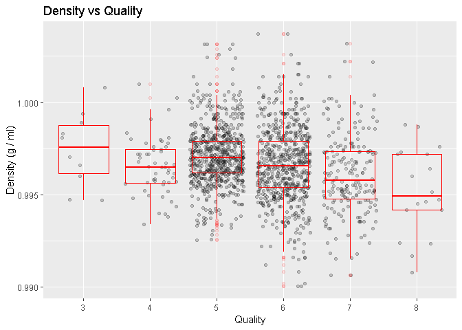

Although there appears to be a slight negative relationship between quality and density, on average the actual range of values is only about 0.0025 difference between the highest and lowest rating.

We then plot scatterplots of the significant variables with a trend line. Since they are quantitative variables, scatterplots are appropriate.

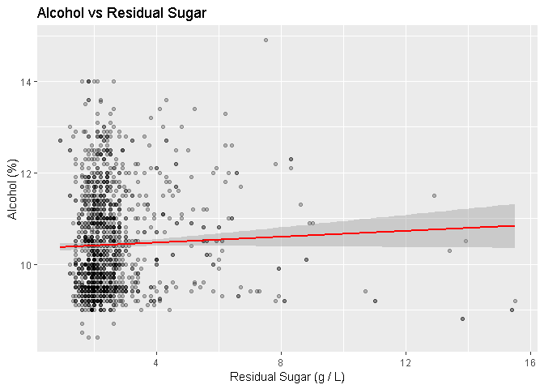

There does not seem to be much correlation between the alcohol content and the amount of residual sugar. Most of the wines have a residual sugar amount between 1.5 and 3 g/L regardless of alcohol content.

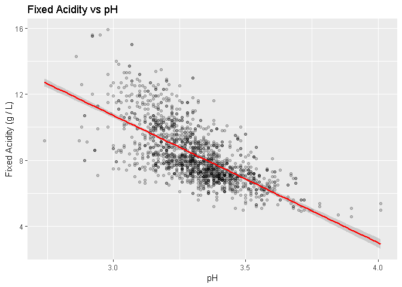

We see that as the fixed acidity decreases the pH increases, which makes sense since higher pH values result from less acidic liquids.

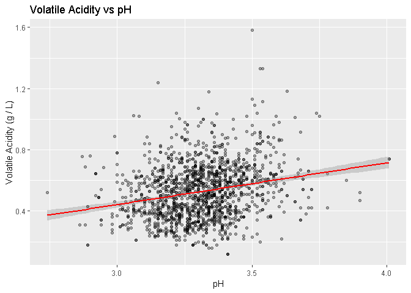

Although, the data is significantly dispersed in the graph, the trend line shows a positive, although not strong, relationship between pH and volatile acidity.

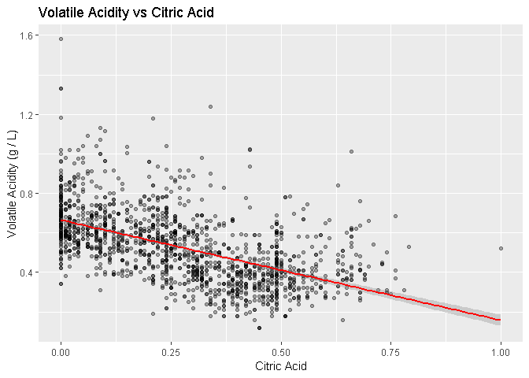

There is a negative and moderate relationship between the volatile acidity and citric acid.

# Bivariate Analysis

### Talk about some of the relationships you observed in this part of the investigation. How did the feature(s) of interest vary with other features in the dataset?

I separately looked into the relationship between quality and several attributes to get an idea of what really affects the quality scores the wines received. I used the correlation results to help guide the attributes I reviewed. The attributes were alcohol content, Sulphates, citric acid, total Sulfur dioxide, volatile acidity, and chlorides. The alcohol content seemed like an obvious attribute to explore. The amount of Sulphates and volatile acidity also show a significant influence on the quality rating. Below is an overview of the attributes direct affect the quality score on average:

. Alcohol vs Quality - generally positive trend except for quality score 5 wines, which showed the lowest alcohol content  
. Sulphates vs Quality - weak positive trend  
. Volatile Acidity vs Quality - negative trend  
. Fixed Acidity vs Quality - not consistent/no affect  
. Residual Sugar vs Quality - neutral level/no affect  
. pH vs Quality - negative trend  
. Citric Acid vs Quality - positive trend  
. Chlorides vs Quality - very weak negative trend  
. Total Sulfur Dioxide vs Quality rating - upward trend until quality score 5 and then downwards

### What was the strongest relationship you found?

Actually, the strongest relationship I found was alcohol content vs quality